# Challenge

Navruzbek Karamatov

March 11, 2019

## Stock returns

Initially, important libraries are called.

```r
library(lubridate)
library(dplyr)
```

First, raw data is imported and all columns are made numeric.

```r
mydata=read.csv("C:/Users/navruzbek/Desktop/r_projects/N225/N225_project/returns_20181228.csv",
                sep=",", dec=".", stringsAsFactors=FALSE, header=TRUE)
mydata2 = apply(mydata[,2:ncol(mydata)], 2, as.numeric)
```

To analyze if stock has momentum or mean reversion Autoregressive (AR) model is fitted. Autoregressive of order 1 shows if the stock returns have a momentum if AR(1) coefficient is significant and large. Thus, only AR(1) is fitted for each stocks and for each month separately.

Data with zeros are labeled “NA” to drop out later.

```r
mydata2 = cbind(mydata[,1], mydata2)
mydata2[ mydata2 == 0 ] = NA
```

Now, month and year information is obtained to roll over them. Also, “newdate” is created to merge the result to it.

```r
mydate = mdy(mydata2[,1])
mymonth=month(mydate) #get the month
myyear=year(mydate) #get the year
mydata2 = cbind(myyear, mymonth, mydata2)

merged_data = c(rep(1990, 12),rep(1991, 12),rep(1992, 12),rep(1993, 12))
merged_data = cbind(merged_data, (rep(seq(1,12,1),4)))
colnames(merged_data) = c('years','months')
```

Now, AR(1) is fitted to each stock and for every month by looping through them. Data is merged to “merged_data” based on month and year information.

```r
for (j in 4:ncol(mydata2)){

  expdata = mydata2[,c(1,2,j)]
  expdata = na.omit(expdata)
  expdata1 = list()
  expdata1 = as.data.frame(expdata1)

  mymonths = unique(expdata[,2])
  myyears = unique(expdata[,1])

  for(m in 1:length(myyears)){
    AA = as.numeric(myyears[m])

    for(i in 1:length(mymonths)){
      BB = as.numeric(mymonths[i])
      if(AA == 1993 & BB == 11){break}
      newdata <- as.data.frame(expdata[ which( expdata[,1] == AA & expdata[,2] == BB), ])
      if ( nrow(newdata) < 15){break}
      fitted = arima(as.numeric(as.character(newdata[,3])), order = c(1,0,0),method="ML")
      mycoef = as.data.frame(t(c(AA,BB,fitted$coef[1])))
      expdata1 = bind_rows(expdata1, mycoef)
    }
  }
  colnames(expdata1) = c('years', 'months', paste('stock', j-3))
  merged_data = merge(merged_data, expdata1, by=c('years', 'months'), all.x=TRUE)
}
```

After obtaining AR(1) model coefficient for each stock and for each month, the average of coefficient across stocks is obtained by rowmeans.

```r
mean_data_ar = rowMeans(merged_data[,3:ncol(merged_data)], na.rm=TRUE)
mean_data_ar = cbind(merged_data[,1:2], mean_data_ar)
```

From plot it is clear that stocks’ average AR coefficient behaved differenty before and after 28th month which is 4-1992 in our data.

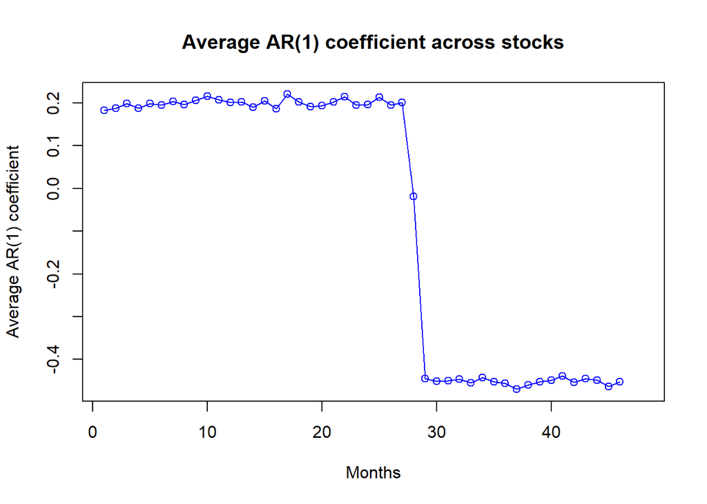

```r
plot(mean_data_ar[,3], type='o', col='blue', ylab='Average AR(1) coefficient',
     xlab='Months', main = "Average AR(1) coefficient across stocks")
```

Now the average AR(1) coefficient across months and stocks obtained before and after 4-1992.

```r
before_28 = mean(mean_data_ar[1:27,3])
before_28
```

```
## [1] 0.1995989
```

```r
after_28 = mean(mean_data_ar[29:46,3])
after_28
```

```
## [1] -0.4516244
```

## Credit card transactions

```r
mydata=read.csv("C:/Users/navruzbek/Desktop/r_projects/N225/N225_project/res_purchase_2014.csv",sep=",", dec=".", stringsAsFactors=FALSE, header=TRUE)
```

Now data should be cleaned before any analysis. Extra letters are removed. Moreover, “(” sign is replaced by “-”.

```r
mydata$Amount2 = gsub("[)$a-z]", "", as.character(mydata$Amount))
mydata$Amount2 = gsub("[(]", "-", as.character(mydata$Amount2))
```

Now sum of total spending is obtained.

```r
sum(as.numeric(as.character(mydata$Amount2)))
```

```
## [1] 188040606
```

Now sum of total spending at “WW GRAINGER” is obtained.

```r
newdata = mydata[which(mydata[,8] == "WW GRAINGER"),]
sum(as.numeric(as.character(newdata$Amount2)))
```

```
## [1] 5089417
```

Now sum of total spending at “WM SUPERCENTER” is obtained.

```r
newdata = mydata[which(mydata[,8] == "WM SUPERCENTER"),]
sum(as.numeric(as.character(newdata$Amount2)))
```

```
## [1] 31777.83
```

Now standard deviation of monthly spending is obtained. First month and year information is extracted from data.

```r
dates = mdy_hm((mydata[,9]))
mymonth = unique(month(dates))
myyear = unique(year(dates))
mydata$year = year(dates)
mydata$month = month(dates)
```

Then, by rolling over months and years, total monthly spending is obtained.

```r
monthlysum=list()
for(i in 1:2){
  AA = myyear[i]
  for(n in 1:length(mymonth)){
    BB = mymonth[n]
    newdata <- as.data.frame(mydata[ which( mydata[,13] == AA & mydata[,14] == BB), ])
    monthlysum[length(monthlysum)+1] = sum(as.numeric(as.character(newdata$Amount2)))
  }
}
```

standard deviation of monthly spending is given below.

```r
monthlysum=as.numeric(monthlysum)
monthlysum = monthlysum[monthlysum > 0 ]
sd(monthlysum)
```

```
## [1] 5642406
```

### Extra analysis of credit card transactions data

#### Average transaction by vendors’ name and category

Here, credit card data is further analyzed by getting the mean of transaction for each vendor name.

By looping through the names of vendors, average transactions are obtained.

```r
vendor_list = unique(mydata[,8])
spending_by_vendor=list()

for(i in 1:length(vendor_list)){
  vendor_name = vendor_list[i]
  temp_data = mydata[which(mydata[,8] == vendor_name),]
  spending_by_vendor[length(spending_by_vendor)+1]=
    mean(as.numeric(as.character(temp_data$Amount2)), na.rm=TRUE)
}
spending_by_vendor = as.numeric(spending_by_vendor)
length(vendor_list)
```

```
## [1] 86727
```

A number of vendors is very big, thus, it takes a little bit time to get the average of transactions for every vendors.

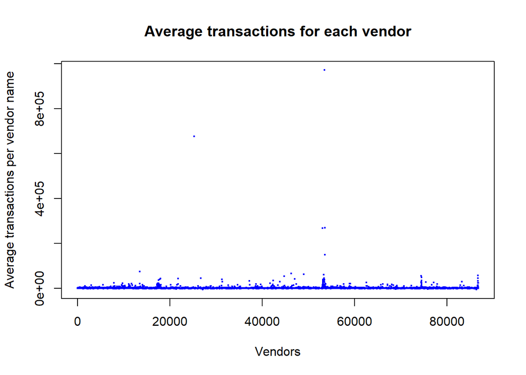

```r
plot(spending_by_vendor, ylab='Average transactions per vendor name', xlab='Vendors',
     main = "Average transactions for each vendor",cex=0.3, col='blue')
```

Clearly data has outliers as displayed by a plot. Some vendors experienced very high transactions.

```r
spending_by_vendor_sorted = sort(spending_by_vendor,decreasing = TRUE)
spending_by_vendor_sorted[1:10]
```

```
##  [1] 972261.50 676960.09 270669.24 269333.12 149500.00  75393.94  65882.75
##  [8]  63959.00  62330.14  57835.05
```

To get the category names of those vendors, data looped again to obtain category names for top 100 vendors only. Categories of vendors that expereinced very high trasactions are given below.

```r
category_type = list()
for(i in 1:100){
  vendor_name = vendor_list[which(spending_by_vendor %in% spending_by_vendor_sorted[i])]
  if(length(vendor_name) > 1){vendor_name = vendor_name[1]}
  temp_data = mydata[which(mydata[,8] == vendor_name),]
  category_type[length(category_type)+1] = temp_data[1,11]
}
category_type=as.character(category_type)
category_type[1:5]
```

```
## [1] "COMMERCIAL EQUIPMENT, NOT ELSEWHERE CLASSIFIED"
## [2] "OTHER FEES"
## [3] "GENERAL CONTRACTORS-RESIDENTIAL AND COMMERCIAL"
## [4] "COMPUTERS, COMPUTER PERIPHERAL EQUIPMENT, SOFTWARE"
## [5] "COMMERCIAL EQUIPMENT, NOT ELSEWHERE CLASSIFIED"
```

Next, frequency of categories is investigated in order to investigate the most frequent categories.

```r
freq.table = table(category_type)
freq.table = freq.table[order(freq.table, decreasing=T)]
freq.table[1:6]
```

```
## category_type
##          COMMERCIAL EQUIPMENT, NOT ELSEWHERE CLASSIFIED
##                                                      10
##                       MISCELLANEOUS GENERAL MERCHANDISE
##                                                      10
## DENTAL/LABORATORY/MEDICAL/OPHTHALMIC HOSP EQIP AND SUP.
##                                                       8
##                                      SOUTHWEST AIRLINES
##                                                       8
##            INDUSTRIAL SUPPLIES NOT ELSEWHERE CLASSIFIED
##                                                       7
##              BUSINESS SERVICES NOT ELSEWHERE CLASSIFIED
##                                                       5
```

Clearly, customers spent huge amount of money especially in vendors operating in commerical equipment, general merchandise and dental categories.

Now, data is checked again for negative average transactions.

```r
spending_by_vendor_sorted = sort(spending_by_vendor,decreasing = FALSE)
spending_by_vendor_sorted[1:10]
```

```
##  [1] -4907.220 -4454.760 -3537.900 -3047.263 -2957.000 -2399.600 -2188.000
##  [8] -2084.520 -2000.000 -1900.870
```

Now, category names are obtained again for top 100 vendors with negative average transactions.

```r
category_type = list()
for(i in 1:100){
  vendor_name = vendor_list[which(spending_by_vendor %in% spending_by_vendor_sorted[i])]
  if(length(vendor_name) > 1){vendor_name = vendor_name[1]}
  temp_data = mydata[which(mydata[,8] == vendor_name),]
  category_type[length(category_type)+1] = temp_data[1,11]
}
category_type=as.character(category_type)
category_type[1:5]
```

```
## [1] "BOOK STORES"
## [2] "MISCELLANEOUS AND SPECIALTY RETAIL STORES"
## [3] "HOBBY,TOY,AND GAME STORES"
## [4] "USED MERCHANDISE AND SECONDHAND STORES"
## [5] "DIRCT MARKETING/DIRCT MARKETERS--NOT ELSEWHERE CLASSIFIED"
```

Next, the frequency of categories is further investigated.

```r
freq.table = table(category_type)
freq.table = freq.table[order(freq.table, decreasing=T)]
freq.table[1:6]
```

```
## category_type
##                          AMERICAN AIRLINES
##                                         36
##                         SOUTHWEST AIRLINES
##                                          6
## STATIONERY,OFFICE AND SCHOOL SUPPLY STORES
##                                          6
##                            UNITED AIRLINES
##                                          6
##                          CATALOG MERCHANTS
##                                          5
##                                      DELTA
##                                          3
```

Airlines are in top 6 categories where customers became indebted for transactions. Obviously, it happened when customers are buying airplane tickets.

#### Total transactions by cardholders’ last name

Next, total transactions by cardholders’ last name is analyzed. However, data contains unreal cardholder names and they are dropped first.

```r
mydata$Cardholder.Last.Name2 = gsub("[0-9]", NA, as.character(mydata$Cardholder.Last.Name))
mydata$Cardholder.Last.Name2 = tolower(mydata$Cardholder.Last.Name2)
mydata$Cardholder.Last.Name2 = gsub("cardholder",
                                    NA,as.character(mydata$Cardholder.Last.Name2))
```

Folowing the cleansing, unique names are obtained and looped through the data to get the sum of transactions for each cardholder’s last name.

```r
card_holder_name = unique(mydata$Cardholder.Last.Name2)
card_holder_name = na.omit(card_holder_name)
spending_by_card_holder_name=list()

for(i in 1:length(card_holder_name)){
  card_name = card_holder_name[i]
  temp_data = mydata[which(mydata$Cardholder.Last.Name2 == card_name),]

  spending_by_card_holder_name[length(spending_by_card_holder_name)+1]=
    sum(as.numeric(as.character(temp_data$Amount2)), na.rm=TRUE)
}
spending_by_card_holder_name = as.numeric(spending_by_card_holder_name)
```

First, top 10 customers with the smallest transactions are shown.

```r
spending_by_card_holder_name_sorted = sort(spending_by_card_holder_name, decreasing = FALSE)
card_holder_name[which(spending_by_card_holder_name %in%
                         spending_by_card_holder_name_sorted[1:10])]
```

```
##  [1] "speight"  "damron"   "cotts"    "smalling" "hodgson"  "mackie"
##  [7] "shockley" "cauthron" "yip ch"   "keenan"   "leas"
```

Next, top 10 customers with the highest transactions are shown.

```r
spending_by_card_holder_name_sorted = sort(spending_by_card_holder_name, decreasing = TRUE)
card_holder_name[which(spending_by_card_holder_name %in%
                         spending_by_card_holder_name_sorted[1:10])]
```

```
##  [1] "hines"                    "cantrell"
##  [3] "johnson"                  "larson"
##  [5] "lewis"                    "mccall"
##  [7] "saltzman"                 "journey house travel inc"
##  [9] "university american"      "stroup"
```

Interestingly, not all customers are individuals but institutions as well, such as “journey house travel inc”.